# Where RACs fall on new shoes

The model of the paper on the 631 new shoes, the comparison with the 386 original shoes, and the goodness of fit Micha asked for. Prepared for Micha Mandel, FSI revision FSI-D-26-01184.

16 November 2026 (revised after an independent line-by-line statistical check) | Branch `feature/new-shoes-finish` | Two collections: 386 original shoes (the model is fitted on them) and 631 new shoes (all used). Numbers come from `processed_data/validation/new/all_new_shoes/` (goodness of fit) and `processed_data/compare/` (original against new).

## In six points

What this section is for: the whole report in six points.

Micha asked for two things at the meeting of 5 November: (1) fit the model of the paper on the new shoes, with the same standardization of the shoe; (2) test whether the surface fitted on the original shoes predicts where RACs fall on the new shoes, by summing p·S with the random effect at 0 over parts of the shoe (Naomi's 14 areas, or a grid of 10 to 20 cells).

1. **Request 1 is done.** The model runs on all 631 new shoes. RAC intensity is again far from uniform, also when whole shoes are resampled (p < 10<sup>−16</sup>). The original results reproduce exactly.
2. **Request 2 is done.** The surface fitted on the original shoes does not transfer: X² = 504 on Naomi's 14 areas, eight times what a correct model would typically give (62; p < 0.001). The 2022 regional model is rejected too (X² = 305).
3. **Where it misfits.** The new shoes have more RACs than predicted at the heel and the rear midfoot and fewer in the central forefoot (Figs. 3–5). Our model's contrasts also look too strong (calibration slope 0.71), clearly on Naomi's areas, but not significantly on the 15-cell grid chosen in advance (0.76, p = 0.075).
4. **Our model against the 2022 model: no predictive advantage.** By the log score (a strictly proper scoring rule) they are indistinguishable per RAC (difference +0.000004, 95% CI −0.0060 to +0.0056); per shoe ours is slightly ahead (+0.0056, CI −0.0011 to +0.0116), not established. By the part counts (X²) the 2022 model does better: clearly on its own 14 areas, borderline on Micha's grids.
5. **Checks.** Same scale and nearly the same shoe size in both collections; the non-uniformity survives a shoe bootstrap in both; the misfit stays with finer spline bases (X² 445–477 on the 14 areas; no bootstrap noise floor was computed for them) and with blocks of shoes resampled together.
6. **Open, for Micha to decide.** The fit has no per-shoe offset; a held-out test within the original shoes has not been run, so we cannot yet say how much of the misfit is the model's own and how much is the new collection's.

## Data

What this section is for: the two collections, and what each is used for.

|  | Original shoes (paper) | New shoes |
| --- | --- | --- |
| Shoes | 386 with RACs (387 in all) | 631, all with RACs |
| RACs | 13,287 | 20,013 |
| Image frame | 307 × 395 px | 255 × 367 px; the same scale, 300 px per unit, after dividing the new coordinates by 2 |
| Role in the goodness of fit | the model is fitted on them | the model is tested on all of them |

Every new shoe is used, with no exclusions. The two collections come from different sources, scans and probably marking rules; the report treats them as two samples of shoes. The 20,013 RACs fall on 19,990 distinct pixels (a few share a pixel).

**What the 631 include.** 67 new prints are of soles also in the original collection (reprints, new prints of the same soles), 22 more are uncertain, and 31 further possible reprints have not been reviewed (all 31 are in the 542 and 631 sets, 25 of them in the 478 set). These counts come from our own comparison of the images; the people who collected the shoes have not confirmed them. 75 prints fail the quality rule (too many RACs off the printed contact, as with faint or partial prints), 64 of them apart from the reprints. The earlier version of this report left out the reprints, the uncertain ones and the poor prints (478 shoes), as planned in advance. With all 631 the main conclusions are the same; the per-shoe comparison with the 2022 model depends on the shoe set: on all 631 its two-sample interval includes 0 (see the results), on some other sets, e.g. the 453 shoes without any candidate reprint, it excludes 0 (+0.0002 to +0.0155). X² grows with the number of RACs, so the last column gives it per RAC. Per RAC, the misfit rises mainly when the poor prints are added (0.0218 → 0.0247); the reprints add little (→ 0.0252):

| New shoes used (14 areas, our model) | Shoes | X² | Noise floor | X² per RAC |
| --- | --- | --- | --- | --- |
| Without reprints and poor prints (planned set) | 478 | 298 | 49 | 0.0218 |
| Without reprints and uncertain ones; poor prints kept | 542 | 398 | 54 | 0.0247 |
| All (this report) | 631 | 504 | 62 | 0.0252 |

The reprints share soles with the original collection, so the two samples are not fully independent; the bootstrap ignores this. Leaving out also the 31 unreviewed candidates (453 shoes) gives X² 263 and moves the per-RAC comparison toward our model by +0.0023 nats (interval reaching +0.0078), still not established.

## The two maps, original and new

What this section is for: the final maps of our model on each collection, and how to compare them fairly.

These are the final maps of our model: the RAC intensity at each pixel of the standardized shoe, as plotted by the paper's code: the intensity at random effect 0, multiplied by exp(−σ²/2) (0.62 original, 0.69 new) and shifted by each collection's mean offset. The toe is at the top, the heel at the bottom.

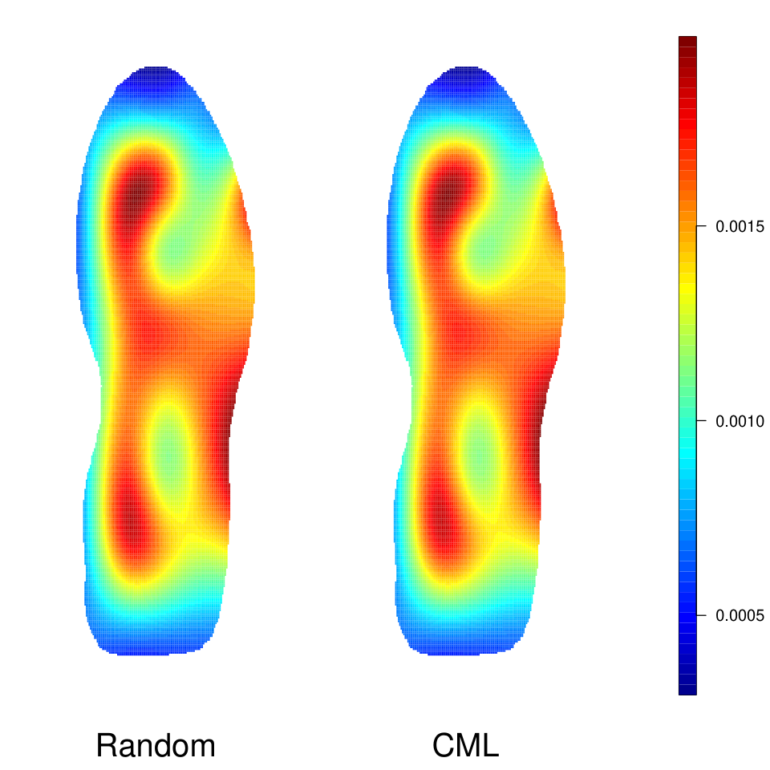

**Fig. 1a. Original shoes, 386.** Random effects (left) and conditional maximum likelihood, CML (right). `model_images/pixel_inten_JASAup.pdf`

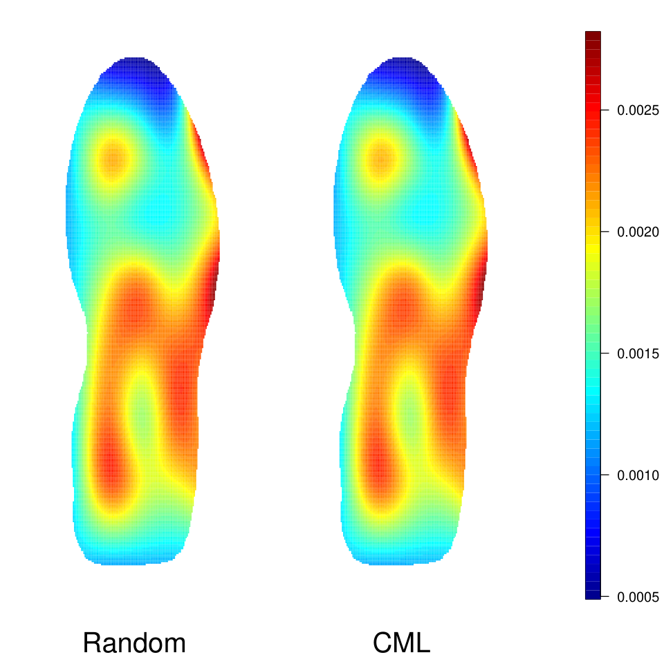

**Fig. 1b. New shoes, 631.** Random effects (left) and CML (right). `model_images/new/pixel_inten_JASAup_new.pdf`

Random effects and CML agree in shape within about 2% on both collections (the CML map's level is set equal to the random-effects map's), so neither shape depends on the estimation method.

**Read the shapes, not the colours.** Each map has its own colour scale: the original one runs up to about 0.0020 and the new one up to about 0.0028. The rainbow palette turns a 20% change into a jump from yellow to red. The new map is on average about 1.36 times higher. About 1.11 of this is the plotting factor exp(−σ²/2) (σ² 0.96 against 0.76), a convention, not data. The remaining 1.23 is real for a typical shoe: a typical new print has slightly more RACs (about 6%) on about 14% less contact area (geometric mean) (median per-shoe density 1.20 times higher, 95% CI 1.03–1.41, shoe bootstrap). Pooled over all RACs the density differs by only 6% (0.93–1.22), because the original collection has more very densely marked shoes. A version of Figs 1a and 1b on one colour scale: `model_images/compare/fig1a_original_common_scale.png and fig1b_new_common_scale.png`.

### The shapes compared properly

Figure 2 removes the colour-scale problem. It divides each collection's map by its own overall RAC density, so only the *shape* is compared: red means the new shoes have relatively more RACs there, blue relatively fewer, white the same. Both fits use the same knots. Left: from the model; right: from the raw RAC counts, with no model.

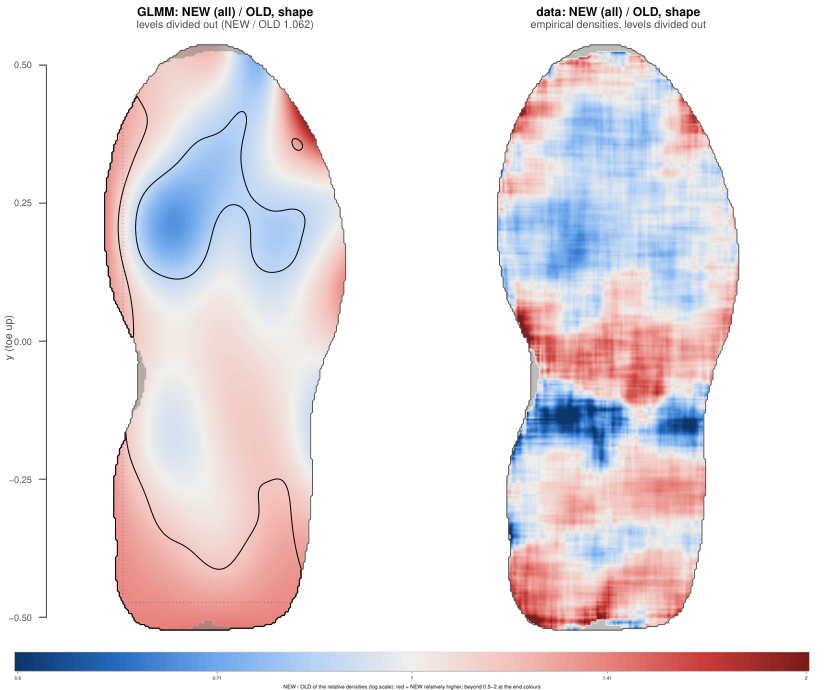

**Fig. 2. Shape only: new / original.** Each collection's map divided by its own overall density. Left: our model (black line: shoe-bootstrap |z| = 1.96, pointwise, not adjusted for multiplicity; dotted: a band the model holds fixed by construction). Right: the raw data in a 21 × 21-pixel box. Grey (both panels): fewer than 10 RAC pixels of either collection in the box. `model_images/compare/ratio_maps_commonbasis_shape_boot_old_vs_new.pdf`, the two panels with all new shoes

The two surfaces are close over most of the shoe. Relative to its own total, the new collection is lower in a patch of the central forefoot and higher at the heel bottom (both panels) and, in the data only, in a band across the top of the midfoot. The raw data also show a narrow band of fewer RACs at the front of the heel, which the model's smooth surface does not follow.

The test that the two shapes are equal (the 24 spatial coefficients, shoe bootstrap) is significant: W = 46.7 on 24 terms, p = 0.0056, without the 89 reprints and uncertain prints (the primary test, closest to independent samples; 31 unreviewed possible reprints remain in it); with all shoes W = 51.9, p = 0.0014. The overall level is not significantly different (new / original 1.06, 95% CI 0.93–1.22); that is a lack of evidence for a difference, not evidence that the levels are equal.

### Region by region (exploratory)

The regions below were chosen *after* looking at Fig. 2, so their intervals are descriptive: they would hold their 95% only for regions fixed in advance. Shape ratios new / original from the raw data, whole-shoe bootstrap:

| Region (y from heel −0.5 to toe 0.5, as in Fig. 2) | New / original, shape |
| --- | --- |
| Band at the top of the midfoot (−0.05 < y < 0.05) | 1.25 (1.10–1.42) |
| Heel bottom (y < −0.35) | 1.15 (1.05–1.28) |
| Band at the front of the heel (−0.18 < y < −0.12) | 0.59 (0.44–0.83); mostly one group of 392 new shoes, probably a single sole design (see "Why the maps differ") |
| Central forefoot | 0.82 (0.72–0.94) |
| Right toe (the red corner of the model map) | 0.95 (0.79–1.15) over the right half of the toe; the red corner itself is small and holds few RACs: not established either way, possibly a spline edge effect |
| Right forefoot rim | 1.07 (0.90–1.26): not in the data |

### Why the outline is the same

Both maps are drawn on the same shoe on purpose. That is the standardization Micha asked for: every RAC is moved from its own shoe onto the original prototype. For each RAC, the pipeline measures its distance from the centre line as a share of its own shoe's half-width on that side at that height, and puts it at the same share on the prototype (`new_x = x · distance_shape / (|x| + horiz_dist)`); y is kept as it is. The new shoes use the *original* prototype, so both models live in one coordinate system; without it the goodness of fit, which applies the original fit to the new shoes, could not run.

### Why the maps differ

The data point to four causes; they cannot tell which one matters most.

[output not shown]

For the paper: this is Reviewer 1's point 4 and the editor's sole-design point. One surface for all shoes is an approximation, and RAC locations depend partly on the sole design.

## Request 1: the model on the new shoes

What this section is for: Micha's first request. The model of the paper, fitted again on the new shoes.

The outline of every shoe is found by an active contour (the "snake"). All 631 outlines were built and checked by eye three times. Frame artefacts and debris were erased on 11 shoes (the new prints carry no stickers); 24 shoes needed a fallback setting (22 a larger closing radius of 24, one a radius of 16, and one its own starting ellipse). The outlines meet the quality criteria set on the original shoes, with a few exceptions (for example, 9 shoes with some sole beyond the prototype mask and 7 with a pad rim cut off).

|  | Original | New |
| --- | --- | --- |
| Case-control rows | 51,849 | 83,090 |
| GLMM σ² (without the per-shoe offset, as in the paper) | 0.960 | 0.756 |
| Wald, all 24 spatial terms = 0, model-based (each collection on its own knots) | W = 427.8* | **W = 585.9, p < 10<sup>−16</sup>** |
| CML Wald, exact fit, model-based | 420.7 | 576.0 |
| CML Wald, Efron approximation: model-based (cluster-robust) | 394.2 (234.4) | 580.9 (329.0) |

* With the variance from lme4's RX matrix; the Hessian gives 428.7. The paper should state which.

On the new collection, RAC intensity is again far from uniform. W grows with the number of RACs, so it should not be compared between the collections. A test that allows any dependence within a shoe is in "Checks".

**Reproducibility.** After every step the original pipeline still reproduces the committed files exactly; this rerun on all new shoes writes to its own folder and leaves every earlier result unchanged.

## Request 2: goodness of fit on the new shoes

What this section is for: Micha's second request. Does the model fitted on the original shoes predict where the RACs fall on the new shoes?

As Micha asked: for each new shoe, p·S is summed over each part of the shoe, with our model fitted on the original shoes and the random effect at 0, and scaled to the shoe's observed number of RACs (after this scaling the random effect almost cancels, as the probabilities are small). The parts are Naomi's 14 areas and grids of 10, 15 and 20 cells. The test statistic is Pearson's X² over the parts. Its reference distribution comes from a two-sample shoe bootstrap (B = 2,000) that resamples both the original shoes (refitting the model) and the new shoes, so it includes the estimation error of the original fit, overdispersion and the differences between shoes. A textbook χ² with fixed expected counts would be far too narrow (shown in the pipeline atlas, Fig. P8, available on request).

**Terms used below and in the figures.**

- **Our model** = the continuous model of the paper (random effects, splines), fitted on the original shoes and used unchanged to predict the new ones. "Our model, CML estimate" is the same model estimated by conditional maximum likelihood.
- **2022 model** = Naomi's model of 2022: one constant RAC intensity in each of her 14 areas, also fitted on the original shoes.
- **Predicted (expected)** = the number of RACs a model expects in a part of the shoe; **observed** = the number found there.
- **Noise floor** = the mean X² over the 2,000 bootstrap replicates, i.e. what a correct model would typically give here.
- **p < 0.001**: no bootstrap replicate reached the observed X², so p = 1/2,001 ≈ 0.0005, the smallest value 2,000 replicates can give.
- **Log score** = the average log probability a model gives to where each RAC actually fell. It is a strictly proper scoring rule, the right basis for comparing two models' predictions; a difference in X² is not a proper score: it depends on the partition and on each model's noise floor.

### Main results

[output not shown]

**What the test can and cannot say.** Because each shoe's expected counts are scaled to its observed number of RACs, the test is about the *shape* of the surface, not the number of RACs per shoe; heavily marked shoes weigh most. A rejection means "the model is not exactly right *or* the new shoes differ"; the test cannot separate the two. Our model already misfits Naomi's areas on the original shoes it was fitted on (X² 64 over 14 areas, descriptive): in the same direction as on the new shoes at the rear midfoot and the central forefoot, but not at the heel, where the original shoes have fewer RACs than predicted (0.89 and 0.95). So part of the misfit may be the model's own. A held-out test within the original shoes (fit on part of them, test on the rest) would separate the two; it has not been run.

**Assumptions.** The estimation error of the original fit comes from fast refits of the model (fixed effects at the fitted variance), checked against 8 full refits. Every interval treats the new shoes as independent; resampling blocks of 4 consecutive ids, a proxy for several shoes of one wearer, raises φ from 1.82 to 2.24 and the noise floor from 62 to 67 (95th percentile 119 to 131), far below the observed 504. The model comparison on the grids stays borderline under that resampling.

### What our model predicts in each area

This is Micha's quantity itself. For each of Naomi's 14 areas, our model gives the share of the new shoes' RACs it expects there (the sum of p·S over all new shoes, random effect 0). Figure 3 puts that next to the share actually observed.

**How to read it, with one area.** Take the left heel area. Left shoe: our model expects 6.0% of all new RACs there. Middle shoe: 7.3% were observed. Right shoe: 7.3 ÷ 6.0 ≈ 1.23 (from the unrounded shares), so 23% more RACs than predicted. A perfect model would show the same number on the left and middle shoes, and 1.00 everywhere on the right.

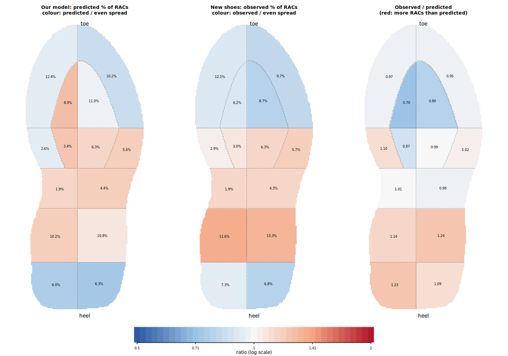

**Fig. 3. Predicted and observed share of RACs per area.** Left: our model, predicted % of the new shoes' RACs in each area; colour = predicted / an even spread over the sole. Middle: observed % on the new shoes; colour = observed / even spread. Right: observed / predicted. 631 new shoes, 20,013 RACs. `model_images/validation/new/all_new_shoes/part2_area_shares_new.png`

Read across: our model expects 10.2% and 10.8% of the RACs in the two rear-midfoot areas, and the new shoes have 11.6% and 13.3% there. It expects 8.9% and 11.0% in the two central forefoot areas, and the new shoes have 6.2% and 8.7%. At the heel it expects fewer RACs than an even spread (6.0% and 6.3%); the new shoes have more than predicted (7.3% and 6.8%), though still fewer than an even spread. Nine of the 14 areas are within one percentage point of the prediction; the ratios range from 0.70 to 1.24.

### Observed / predicted on the shoe

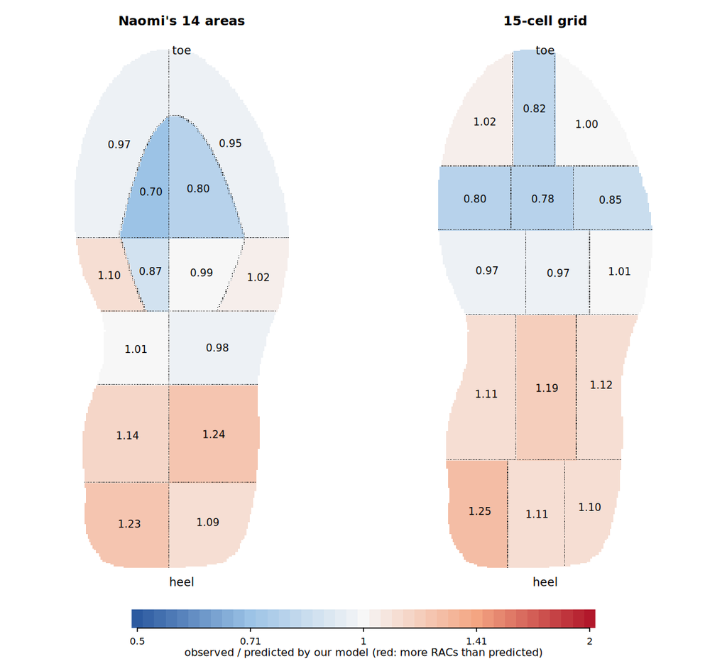

**Fig. 4. Observed / predicted by our model.** Left: Naomi's 14 areas; right: the main 15-cell grid. Red: more RACs than predicted; blue: fewer. `model_images/validation/new/all_new_shoes/part2_oe_simple_new.png`

On Naomi's areas our model is too low at the heel and the rear midfoot (1.09 to 1.24) and too high in the central forefoot and the left-central ball area (0.70 to 0.87). On the 15-cell grid the same pattern appears: the heel band and the rear-midfoot band are red (1.10 to 1.25) and the forefoot band blue (0.78 to 0.85). The 2022 model shows the same pattern, a little more weakly overall but not at the heel (Fig. A3).

### Micha's grid: 10 to 20 cells

The cells are cut on the standardized shoe from the original shoes only, before any new number was computed: five bands from heel to toe, each holding 20% of the original contact area, and each band cut across into 2, 3 or 4 cells, giving 10, 15 or 20 cells (15 was chosen in advance as the main grid).

| Cells | Our model: X² (noise floor) | p | 2022 model: X² (noise floor) | p |
| --- | --- | --- | --- | --- |
| 10 | 351 (52) | < 0.001 | 251 (42) | < 0.001 |
| **15 (main)** | **394 (72)** | **< 0.001** | 289 (51) | < 0.001 |
| 20 | 431 (83) | < 0.001 | 304 (60) | < 0.001 |

### The same ratios with intervals

Figure 5 shows the observed / predicted ratios as dots with pointwise 95% intervals. With 59 intervals per model a few that exclude 1 are expected by chance; the evidence is the consistent gradient from heel to forefoot, which the global test assesses.

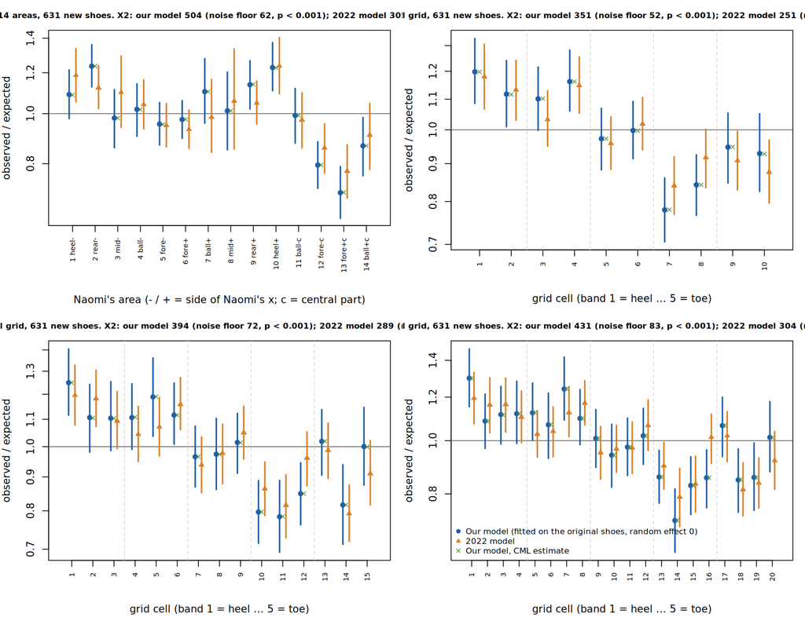

**Fig. 5. Observed / predicted with pointwise 95% bootstrap intervals, per part of the shoe.** Blue: our model; orange: the 2022 model; green ×: our model by CML. Panel titles give each partition's X² and noise floor; they are cut off at both ends in this rendering, and all their values are in the tables above. The y axis "observed / expected" means observed / predicted. "−" areas are on the right of the maps and "+" areas on the left; "c" marks the central areas. Grid cells run in five bands (dashed lines) from heel (1) to toe. `model_images/validation/new/all_new_shoes/part2_obs_exp_new.png`

### Is the test itself right?

A simulation with the model true and no difference between collections: real shoe structure (60 original-like and 100 new-like shoes), 400 replicates. It was run once for the earlier version and not repeated for the 631 shoes.

- Pass. The goodness-of-fit test on Naomi's 14 areas rejects a true model 5.2% of the time at the 5% level (Monte Carlo error about 1.1 points).
- Pass, but conservative. The intervals that include the estimation error of the original fit cover 99.3–99.5% instead of 95%, so they are too wide; "includes 0" with these intervals is weaker evidence than it looks.
- Fail. The log-score intervals with the original fit held fixed cover 91% instead of 95%, so they are slightly too narrow. The headline per-RAC interval above is the wider one.

The simulation is smaller than the real data, and the fast refits were compared with full refits on 8 resamples only.

## Checks

What this section is for: four questions a reviewer could raise, and the answers.

### Are the new shoes on the same scale, and the same size?

The new images are smaller, but that is the frame, not the shoe. The scale calibration gives the same pixel size in both collections (within about 1%), and the shoes have nearly the same size in pixels:

| Snake outline | Original (386) | New (631) |
| --- | --- | --- |
| Length, median (10%–90%) | 311 px (302–317) | 314 px (306–319) |
| Width, median (10%–90%) | 119 px (112–127) | 122 px (115–132) |
| Outline perimeter, median | 700 px | 709 px |

New shoes are about 1% longer and 2.5–3% wider (medians and means), a small but systematic difference. The standardization rescales x but keeps the raw y, so equal lengths matter, and they hold. What is smaller on new shoes is the contact area inside the outline (−12% median, −14% geometric mean): less of the sole touches the paper.

### Does non-uniformity survive the dependence between RACs?

The Wald tests above treat RACs as independent. Resampling whole shoes (1,000 shoe-bootstrap refits of the fixed effects per collection, by fast PIRLS fits with σ² held at its fitted value) allows any dependence within a shoe.

| All 24 spatial terms = 0 (GLMM) | Model-based W | Shoe-bootstrap W | p |
| --- | --- | --- | --- |
| Original, 386 shoes | 427.8 | 255.3 | < 10<sup>−16</sup> |
| New, 631 shoes (original knots) | 623.1 | 377.1 | < 10<sup>−16</sup> |

W drops by about 40% once the dependence is allowed for, and the conclusion does not move: any reasonable reference distribution gives p far below 10<sup>−16</sup>. The cluster-robust CML (Efron approximation) agrees: original 234.4, new 353.9 on the original knots (329.0 on its own knots).

### Do the knots matter?

The paper's basis has 3 knots across the shoe and 5 along it. Cross-validation by shoe (5 folds, CML fits; standard errors approximate):

- **Original shoes:** the finest basis does not beat the paper's basis (z = −0.9); the other finer bases change the held-out log score by −19 to +4 log-likelihood units (13,249 RAC pixels).
- **New shoes:** the finest basis predicts better (z = 2.1) and removes most of the heel-front misfit.
- **Goodness of fit with other bases for the original fit:** X² on Naomi's areas falls from 504 to 445 (finer basis along the shoe) and 477 (full tensor), still 1.5–1.6 times the 2022 model's 305. These fits have no bootstrap of their own, so no p-value is available. A finer basis reduces the misfit only slightly; most of it does not come from the paper's knots, though this is not tested formally.

Two further sensitivity runs change X² by less than 1%: counting each RAC pixel once (503) and dropping pixels outside the original basis' boundary knots (501).

### Is the 2022 comparison fair?

Naomi's original `optim` call stops at its iteration limit, so its intensities are up to 9.8% from the optimum (well within sampling error, so immaterial for her conclusions). The goodness of fit does not use that call: the 2022 model is refitted by its exact conditional maximum likelihood on our contact surface, and refitted again in every bootstrap resample. It has one advantage built in: Naomi's 14 areas are its own partition, so X² on those areas favours it. That is why the grids and the log score matter for the comparison.

## Draft answer to the journal's Reviewer 1

What this section is for: Reviewer 1 asked what the paper adds beyond Naomi's 2022 paper (point 1) and for validation on real out-of-sample data (point 6). Below is a **first draft** of a paragraph for our response letter. Micha and Naomi decide what we answer; its last sentences narrow what the paper claims, which only they can decide.

> We applied the model to a second collection of 631 shoe prints, all included. Our image comparison suggests that about 67 of them are new prints of soles in the original collection (22 more uncertain, 31 further candidates not reviewed; to be confirmed by the collectors), so the full set is partly in-sample; 75 fail a pre-specified quality rule. Leaving out the suspected reprints and the poor prints (478 prints, the out-of-sample set planned in advance) gives the same main conclusions with a smaller misfit. The spatial non-uniformity of RAC locations replicates, also under a bootstrap that resamples whole shoes (p < 10<sup>−16</sup>). The surface fitted on the original collection transfers only partly: a goodness-of-fit test that accounts for the estimation error of the original fit rejects exact transfer (p < 0.001), and the 2022 regional model is rejected as well. The new prints have more RACs than predicted at the heel and rear midfoot and fewer in the central forefoot, and the predicted contrasts may be somewhat too strong: the calibration slope is 0.71 on the 2022 regions and 0.69 at pixel level (both significant), and 0.76 on the grid fixed in advance (one-sided p = 0.075). Per RAC, we find no detectable difference between the continuous surface and the 2022 regional model (log score difference 0.000 nats, 95% CI −0.006 to +0.006); on its own 14 areas the 2022 model fits the new prints better; on grids the difference is borderline. The overall RAC density does not differ significantly between the collections (ratio 1.06, 95% CI 0.93–1.22). RACs within a shoe are not independent: pairs 2–8 pixels apart are 33% (new) and 45% (original) more frequent than independent placement on each shoe's smoothed surface predicts (this does not separate clustering from fine shoe-specific patterns). We therefore present the model as a description of where single RACs tend to occur, not as a tool to compute the probability of a set of RACs. Because the collections differ in source, scanning and marking, the misfit may reflect a different population as much as model error; we discuss sole design and these differences as limitations.

## Open questions

What this section is for: decisions and checks still needed before the numbers are final.

[output not shown]

## Appendix: further figures

What this section is for: extra figures that repeat or extend the ones above.

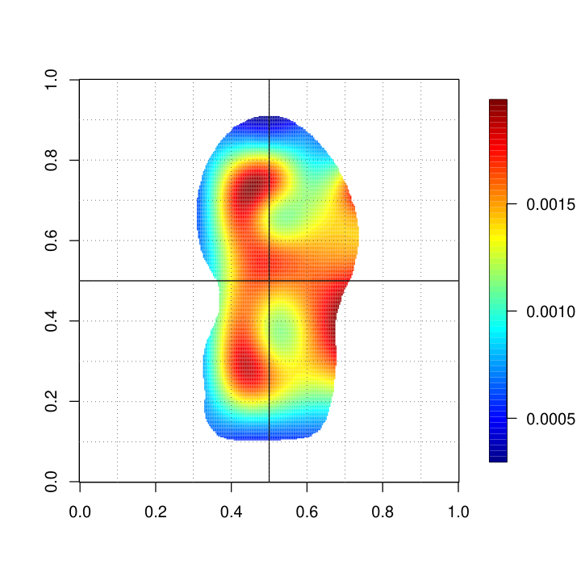

**Fig. A1a. Original shoes,** intensity fitted by the random-effects model on the standardized shoe, with coordinates (own colour scale). `model_images/NEW_X_NS_XY_SHOE.pdf`

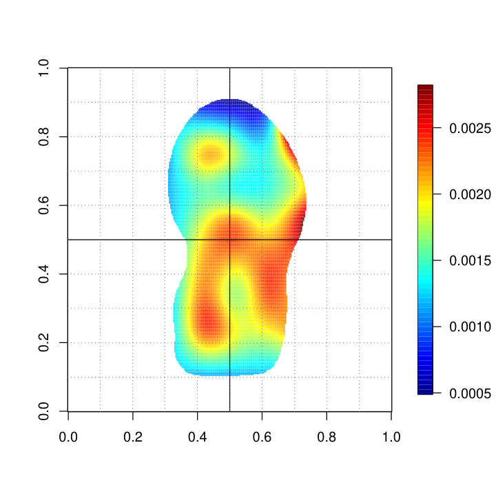

**Fig. A1b. New shoes,** the same map (own colour scale; compare shapes only, or use Fig. A2). `model_images/new/NEW_X_NS_XY_SHOE_new.pdf`

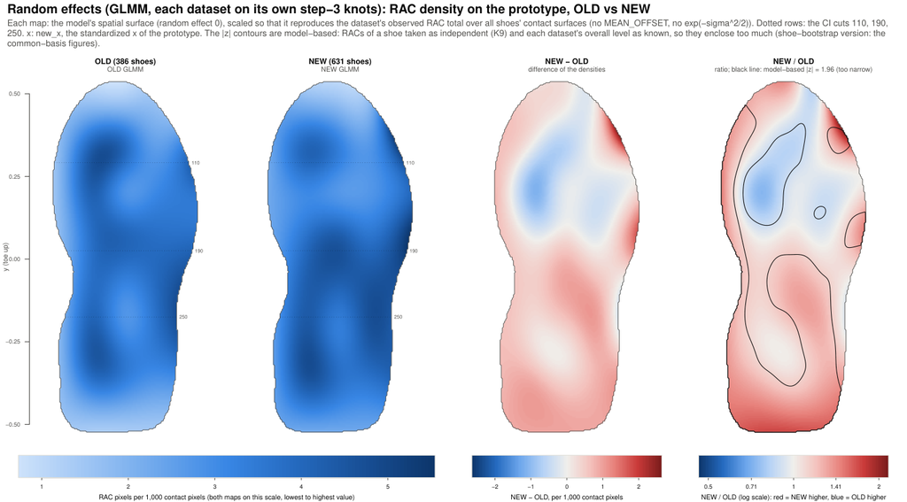

**Fig. A2. One absolute scale.** Each collection on its own knots. From left: original, new (same scale), new − original, new / original (ratio panel: the black contour marks model-based |z| = 1.96; because it treats RACs as independent it overstates where the difference is significant; the panel headers keep internal labels: OLD = original, NEW = new). Units: RAC pixels per 1,000 contact pixels, each map scaled to its observed total. `model_images/compare/intensity_maps_glmm_old_vs_new.pdf`

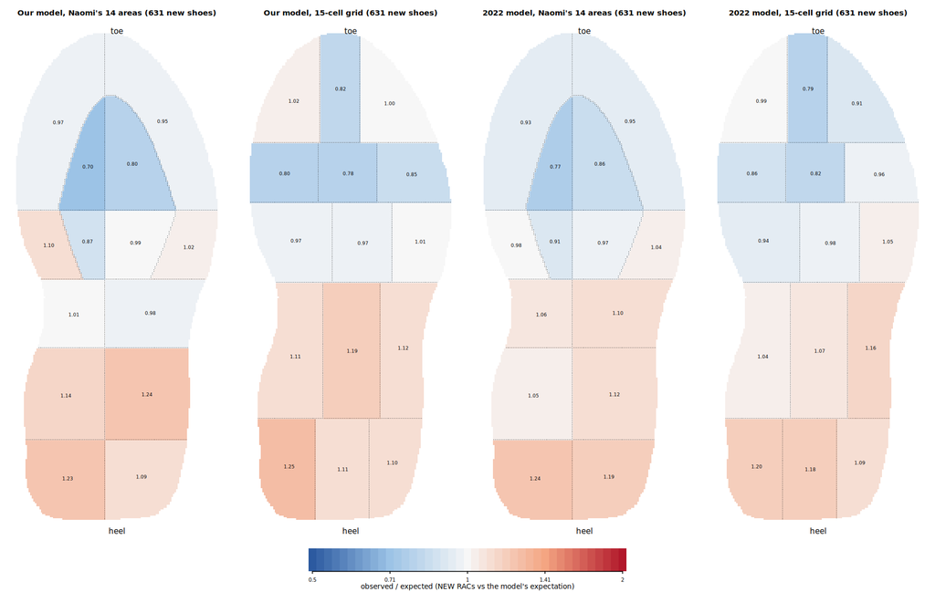

**Fig. A3. Our model and the 2022 model, 14 areas and 15 cells.** Observed / predicted (red: more than predicted; blue: fewer). From left: our model on the 14 areas and on 15 cells, the 2022 model on the 14 areas and on 15 cells. 631 new shoes. `model_images/validation/new/all_new_shoes/part2_cells_map_new.png`

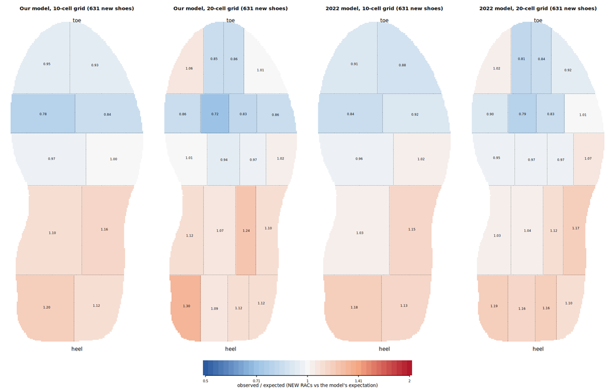

**Fig. A4. The 10- and 20-cell grids.** From left: our model with 10 and 20 cells, the 2022 model with 10 and 20 cells. 631 new shoes. `model_images/validation/new/all_new_shoes/part2_cells_map_g20_new.png`

## How the work was done

What this section is for: the timeline, and how the work was checked.

[output not shown]

Details: `docs/progress/LOG.md`, `docs/decisions.md`, `docs/results/validation.md`, `docs/results/old-vs-new.md`. Rerun: `RAC_PART2_SHOESET=all` in `statistical_model/validation_8.Rmd`.